# 4 Communication

```r
library(tidyverse)
library(ggpp)
library(ggrepel)
```

## 4.1 Plotting

### 4.1.1 `ggpp`

The [ggpp](https://cran.r-project.org/web/packages/ggpp/vignettes/grammar-extensions.html) package allows natural placement of text in ggplots based on position within frame instead of variable values. This is an extension to the Grammar of Graphics (r-project.org).

The key function here is `geom_text_npc`, as in this example:

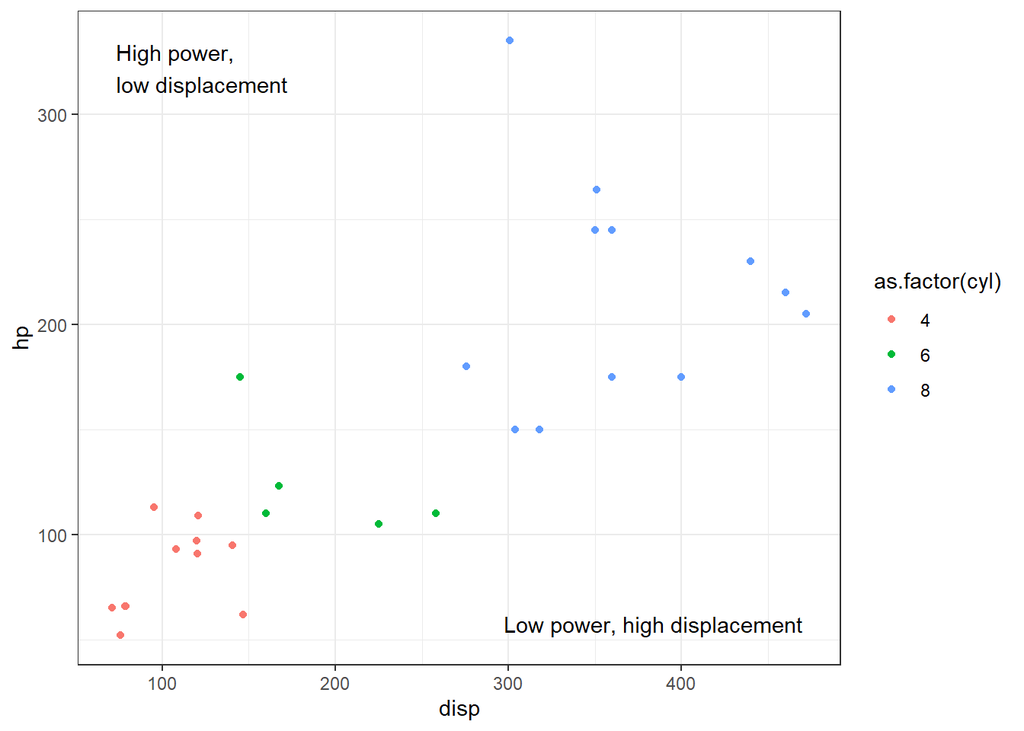

```r
df.lab = tibble(x = c("left", "right"), y = c("top", "bottom"),
                label = c("High power,\nlow displacement", "Low power, high displacement"))
gp1 = ggplot(mtcars, aes (x = disp, y = hp, col = as.factor(cyl)))+
         geom_point()+
  theme_bw()+
  geom_text_npc(data = df.lab, aes(npcx = x, npcy = y, label = label))
gp1
```

The big advantage here is that the text is placed based on the *window* rather than x or y coordinates, so changinge the data or x or Y limits doesn’t screw up text placement in relation to the window.

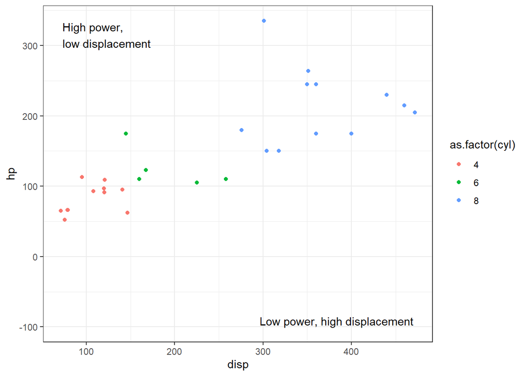

```r
gp1 + ylim(c(-100, NA))
```

When adding text directly (not from dataframe), `ggpp` overwrites the `annotate` function to support natural placement.

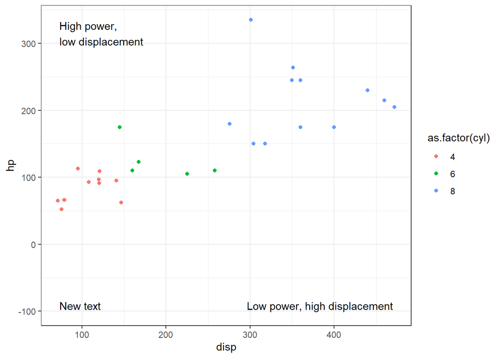

```r
gp1 +
  ylim(c(-100, NA))+
  annotate(geom = "text_npc",
           npcx = "left",
           npcy = "bottom",
           label = "New text")
```

`ggpp` is also great to inset tables (`geom_table()`), plots (`geom_plot()`) or images (`geom_grob()`) within each plot.

One way to inset a table with `geom_table()`, which takes a tibble in which one object is itself a list of the desired table contents. This feels a little fiddly to me, but probably scales up well when making many figures.

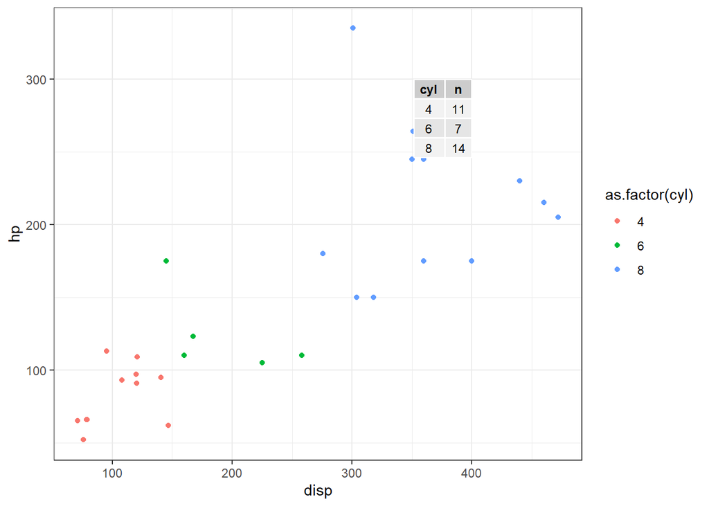

```r
df = mtcars |>
  group_by(cyl) |>
  summarize(n = n())
df.inset = tibble(x = 400, y = 300, tb = list(df))
ggplot(mtcars, aes (x = disp, y = hp, col = as.factor(cyl)))+
         geom_point()+
  geom_table(data = df.inset, aes(label = tb, x = x, y = y))+
  theme_bw()
```

We can also control this more “naturally” with the overwritten `annotate` function – no need to make a tibble containing a tibble or specify locations in absolute x and y coordinates.

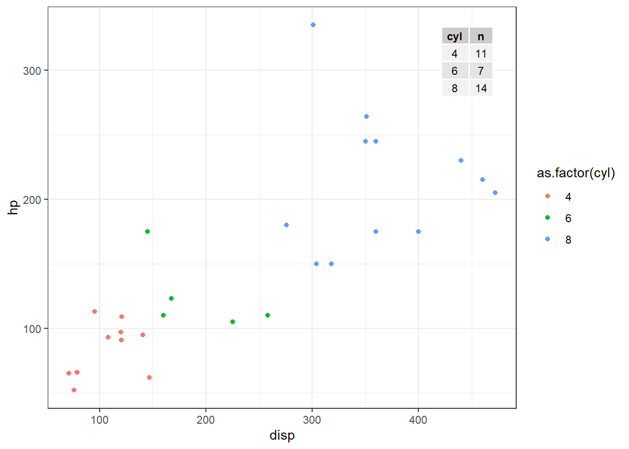

```r
ggplot(mtcars, aes (x = disp, y = hp, col = as.factor(cyl)))+
         geom_point()+
  annotate("table_npc", npcx = "right", npcy = "top", label = df)+
  theme_bw()
```

This same `annotate` approach can be used to add a plot inset into the figure. Make the inset plot and assign it to a variable, then use annotate with “plot_npc” like so:

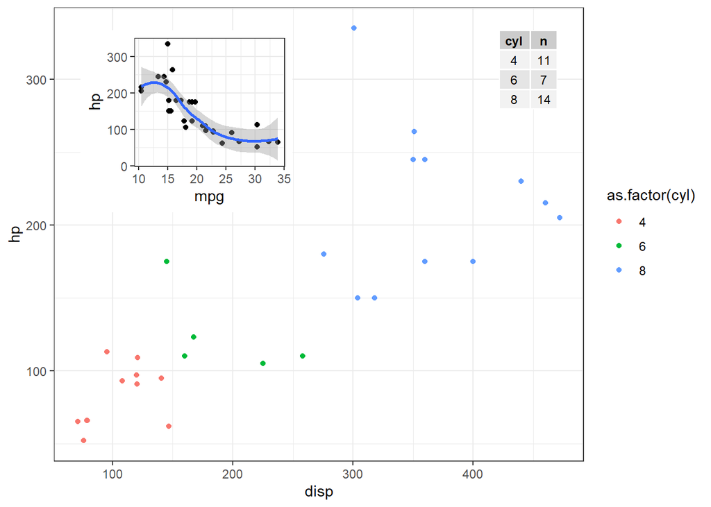

```r
gp.inset = ggplot(mtcars, aes(x = mpg, y = hp))+
  geom_point()+geom_smooth()+
  theme_bw()
ggplot(mtcars, aes (x = disp, y = hp, col = as.factor(cyl)))+
         geom_point()+
  annotate("table_npc", npcx = "right", npcy = "top", label = df)+
  annotate("plot_npc", npcx = "left", npcy = "top", label = gp.inset)+
  theme_bw()
```

### 4.1.2 `ggrepel`

The `ggrepel` package can be used to annotate data points using repultsion to minimize point overlap.

The problem:

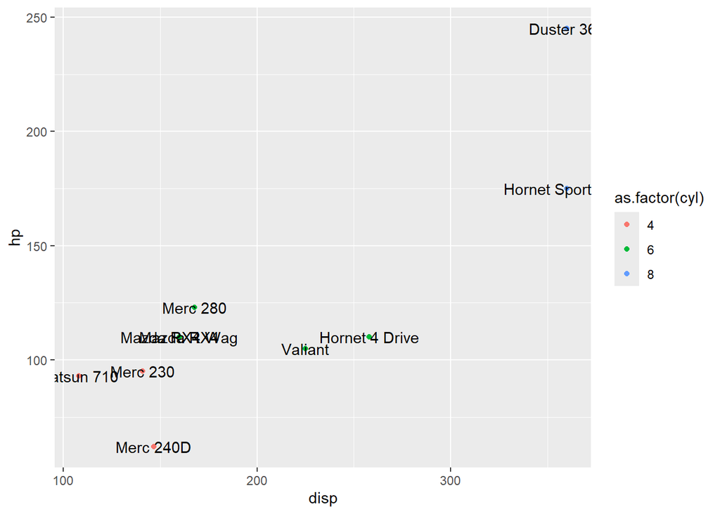

```r
dat = mtcars |>
  head(10)
dat$name = rownames(dat)
ggplot(dat, aes(x = disp, y = hp, col = as.factor(cyl)))+
  geom_point()+
  geom_text(aes(label = name), col = 'black')
```

The solution:

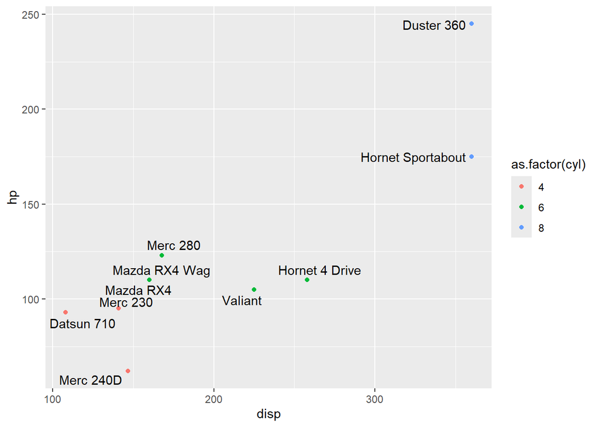

```r
ggplot(dat, aes(x = disp, y = hp, col = as.factor(cyl)))+
  geom_point()+
  geom_text_repel(aes(label = name), col = 'black')
```

### 4.1.3 Custom labeling

Sometimes we want to add content to ggplot in different layers, but have a legend that correctly represents these layers. The solution is to add the desired graphical setting (e.g., color, shape, etc) in the `aes()` call of each layer, and assign a character atomic to that argument. This will then distinguish the graphical setting just like when we assign a character vector column of the dataframe to the graphical argumnet. The `lab()` function can be used to give a meaningful legend title, and the standard modification functions (e.g. `scale_color_manual`) can be used to specify the colors (or shape, or size, etc) associated with each layer.

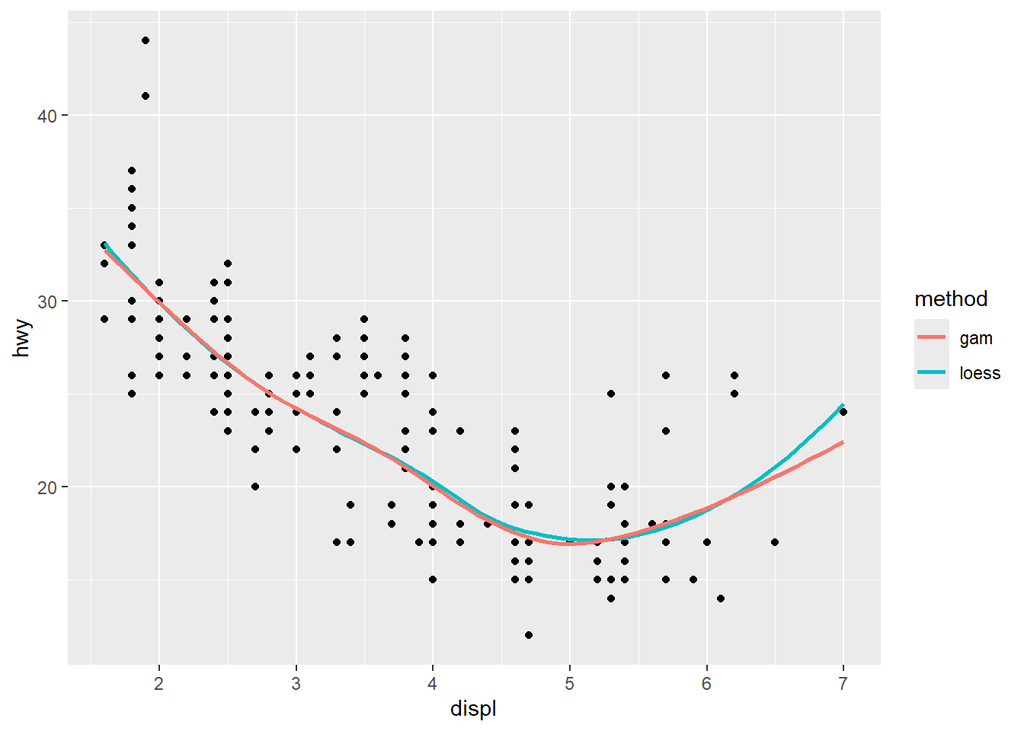

```r
ggplot(mpg, aes(displ, hwy)) +
  geom_point() +
  geom_smooth(aes(color = "loess"), method = "loess", se = FALSE)+
  geom_smooth(aes(color = "gam"), method = "gam", se = FALSE)+
  labs(color = "method")
```

## 4.2 Interactives

## 4.3 Tables

## 4.4 Flowcharts

Quarto has built-in support for generating flow charts and other diagrams from markdown. See here: [Quarto - Diagrams](https://quarto.org/docs/authoring/diagrams.html). This uses `mermaid` and/or `GraphViz`. For live building of these tools, see:

- [Online FlowChart & Diagrams Editor - Mermaid Live Editor](https://mermaid.live/)
- [Graphviz Online (dreampuf.github.io)](https://dreampuf.github.io/GraphvizOnline/)

Here’s the default chart of the mermaid live editor as an example

```
flowchart TD
    A[Christmas] -->|Get money| B(Go shopping)
    B --> C{Let me think}
    C -->|One| D[Laptop]
    C -->|Two| E[iPhone]
    C -->|Three| F[fa:fa-car Car]
```